# Practical Machine Learning Project

Katie T

8/19/2022

## Executive Summary

In this analysis, we will be building a model to predict the manner (classe) in which a user exercises using data of accelerometers on the belt, forearm, arm, and dumbbell of 6 participants. We tested three different methods(random forest, gradient boosting machine, and linear discriminant analysis) and found our random forest model preforms best. Finally we applied this model to the data set pml-testing to predict the manner in which the users performed the exercises.

## Exploratory Analysis

Graph 1 shows the frequency of the classe variable. From this we see that A is the most common outcome for classe in our data set.

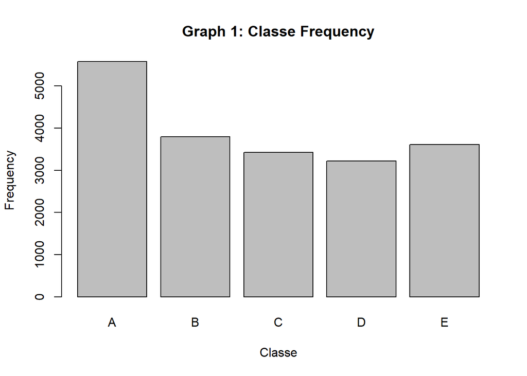

Further we see that the aggregated variables are mostly missing so we will remove these for the analysis. This leaves the following columns for the analysis:

```
##  [1] "roll_belt"            "pitch_belt"           "yaw_belt"
##  [4] "total_accel_belt"     "gyros_belt_x"         "gyros_belt_y"
##  [7] "gyros_belt_z"         "accel_belt_x"         "accel_belt_y"
## [10] "accel_belt_z"         "magnet_belt_x"        "magnet_belt_y"
## [13] "magnet_belt_z"        "roll_arm"             "pitch_arm"
## [16] "yaw_arm"              "total_accel_arm"      "gyros_arm_x"
## [19] "gyros_arm_y"          "gyros_arm_z"          "accel_arm_x"
## [22] "accel_arm_y"          "accel_arm_z"          "magnet_arm_x"
## [25] "magnet_arm_y"         "magnet_arm_z"         "roll_dumbbell"
## [28] "pitch_dumbbell"       "yaw_dumbbell"         "total_accel_dumbbell"
## [31] "gyros_dumbbell_x"     "gyros_dumbbell_y"     "gyros_dumbbell_z"
## [34] "accel_dumbbell_x"     "accel_dumbbell_y"     "accel_dumbbell_z"
## [37] "magnet_dumbbell_x"    "magnet_dumbbell_y"    "magnet_dumbbell_z"
## [40] "roll_forearm"         "pitch_forearm"        "yaw_forearm"
## [43] "total_accel_forearm"  "gyros_forearm_x"      "gyros_forearm_y"
## [46] "gyros_forearm_z"      "accel_forearm_x"      "accel_forearm_y"
## [49] "accel_forearm_z"      "magnet_forearm_x"     "magnet_forearm_y"
## [52] "magnet_forearm_z"     "classe"
```

## Method

We create a training and testing sets with the training set consisting of 70% of the data set. We will use cross-validation within model to uses to compare the models. The test set will be used to do a final validation on the chosen model. Next, we preprocess the data using principal component analysis with p=.7. We will then use this data to run the three models as well as use the same method to preprocess the testing set. We also use trainControl function with method=“cv”and number=10 in order to use in each of the models to preform cross validation.

### Random Forest

We first create a random forest model using the new training set.

```
##
## Call:
##  randomForest(x = x, y = y, mtry = min(param$mtry, ncol(x)))
##                Type of random forest: classification
##                      Number of trees: 500
## No. of variables tried at each split: 2
##
##         OOB estimate of  error rate: 3.92%
## Confusion matrix:
##      A    B    C    D    E class.error
## A 3817   24   34   25    6  0.02278546
## B   64 2520   58   12    4  0.05191874
## C   21   36 2296   33   10  0.04173623
## D   18    9  107 2110    8  0.06305506
## E    4   19   25   21 2456  0.02732673
```

### Gradient Boosting Machine

Next, we create a model using gradient boosting machine.

```
## A gradient boosted model with multinomial loss function.
## 150 iterations were performed.
## There were 12 predictors of which 12 had non-zero influence.
```

### Linear Discriminant Analysis

Finally we create a model using linear discriminant analysis.

```
## Call:
## lda(x, grouping = y)
##
## Prior probabilities of groups:
##         A         B         C         D         E
## 0.2843416 0.1934920 0.1744195 0.1639368 0.1838101
##
## Group means:
##           PC1        PC2        PC3        PC4         PC5         PC6
## A  0.61779644  0.3429863 -0.7636455  0.2337554  0.21936047  0.35110482
## B -0.15770517 -0.2300517  0.4550703 -0.1489125 -0.18274914 -0.06819142
## C  0.08800314  0.1059789 -0.5449385  0.1110691  0.04205471 -0.16343595
## D -0.44352983 -0.2542848  0.5854064 -0.2047021 -0.27445093  0.08093972
## E -0.47760749 -0.1621794  0.6972514 -0.1276720  0.05791114 -0.38845400
##          PC7         PC8         PC9       PC10        PC11       PC12
## A -0.1323617 -0.57863788  0.17698385 -0.2386774  0.11455158  0.1335314
## B  0.1520435  0.27088192  0.48104385 -0.1681554 -0.09641059  0.1404932
## C -0.2891143 -0.13658109 -0.58562862  0.2311670  0.13840053  0.3100178
## D  0.1662205  0.87909577 -0.18290326  0.2137980 -0.13690261 -0.1250692
## E  0.1707971 -0.04448315 -0.06132641  0.1361908 -0.08494341 -0.5370897
##
## Coefficients of linear discriminants:
##              LD1          LD2         LD3          LD4
## PC1  -0.11320914 -0.023333649 -0.02115698 -0.063362870
## PC2  -0.06581737  0.006179312  0.01811444 -0.054277267
## PC3   0.28951584 -0.088573530  0.04517794  0.113038018
## PC4  -0.09011993  0.014263728  0.01898486 -0.040272200
## PC5  -0.09238507 -0.004158735  0.11350328 -0.027295490
## PC6  -0.12344057 -0.083004200 -0.14587105 -0.420815661
## PC7   0.15417330 -0.143114886  0.01923352 -0.061200572
## PC8   0.45830448  0.099530753 -0.41063990 -0.216403802
## PC9  -0.01586613 -0.658664410 -0.12642707  0.108862551
## PC10  0.17478660  0.365956246  0.07277676  0.009248011
## PC11 -0.17541446  0.093950110  0.02580082  0.034051985
## PC12 -0.36623263  0.146566428 -0.70334844  0.452545594
##
## Proportion of trace:
##    LD1    LD2    LD3    LD4
## 0.6545 0.1910 0.1276 0.0270
```

### Model Comparison and Evaluation

Looking at the confusion matrices from the cross-validation we see that random forest model has the highest accuracy and thus the lowest out of sample error (1-accuracy). For this reason we will use the random forest model.

Random Forest:

```
## Cross-Validated (10 fold) Confusion Matrix
##
## (entries are percentual average cell counts across resamples)
##
##           Reference
## Prediction    A    B    C    D    E
##          A 27.8  0.5  0.2  0.2  0.1
##          B  0.2 18.2  0.3  0.1  0.2
##          C  0.2  0.5 16.6  0.8  0.2
##          D  0.2  0.1  0.3 15.3  0.2
##          E  0.1  0.0  0.0  0.0 17.7
##
##  Accuracy (average) : 0.9557
```

```
## Cross-Validated (10 fold) Confusion Matrix
##
## (entries are percentual average cell counts across resamples)
##
##           Reference
## Prediction    A    B    C    D    E
##          A 23.8  2.2  2.0  1.1  1.2
##          B  1.0 13.2  1.2  0.7  1.7
##          C  1.4  2.1 13.3  1.9  1.7
##          D  1.8  1.0  0.5 12.2  1.0
##          E  0.5  0.8  0.5  0.4 12.8
##
##  Accuracy (average) : 0.7537
```

```
## Cross-Validated (10 fold) Confusion Matrix
##
## (entries are percentual average cell counts across resamples)
##
##           Reference
## Prediction    A    B    C    D    E
##          A 18.7  4.9  7.2  1.8  2.8
##          B  1.9  7.0  1.5  3.4  3.4
##          C  2.5  2.8  6.0  1.9  3.0
##          D  3.9  2.4  1.3  7.4  2.1
##          E  1.4  2.3  1.4  1.8  7.1
##
##  Accuracy (average) : 0.461
```

### Model Evaluation

```
## Confusion Matrix and Statistics
##
##           Reference
## Prediction    A    B    C    D    E
##          A 1628    8   23   12    3
##          B   34 1078   15    7    5
##          C    6   12  991   17    0
##          D    9    6   39  906    4
##          E    1    7    7   17 1050
##
## Overall Statistics
##
##                Accuracy : 0.9606
##                  95% CI : (0.9553, 0.9654)
##     No Information Rate : 0.2851
##     P-Value [Acc > NIR] : < 2.2e-16
##
##                   Kappa : 0.9501
##
##  Mcnemar's Test P-Value : 1.179e-07
##
## Statistics by Class:
##
##                      Class: A Class: B Class: C Class: D Class: E
## Sensitivity            0.9702   0.9703   0.9219   0.9447   0.9887
## Specificity            0.9891   0.9872   0.9927   0.9882   0.9934
## Pos Pred Value         0.9725   0.9464   0.9659   0.9398   0.9704
## Neg Pred Value         0.9881   0.9930   0.9827   0.9892   0.9975
## Prevalence             0.2851   0.1888   0.1827   0.1630   0.1805
## Detection Rate         0.2766   0.1832   0.1684   0.1540   0.1784
## Detection Prevalence   0.2845   0.1935   0.1743   0.1638   0.1839
## Balanced Accuracy      0.9796   0.9788   0.9573   0.9665   0.9910
```

### Model Application

Finally we will use the model to predict using the data set pml-testing which produces the following output:

```
##  1  2  3  4  5  6  7  8  9 10 11 12 13 14 15 16 17 18 19 20
##  B  A  A  A  A  E  D  B  A  A  B  C  B  A  E  E  A  B  B  B
## Levels: A B C D E
```